# R Markdown Example

A useful summary of RMarkdown syntax can be found here: https://www.rstudio.com/resources/cheatsheets/

## Formating Text

Enclose parts of text with asterisk to obtain change it to italics or bold: writing `*this text is in italics*` and `**this text is bold**` will result in *this text is in italics* and **this part is in bold** when you knit the document. End a line with two spaces to start a new paragraph.

To include a link use the following `[text for link](www.rstudio.com)` which yields text for link

Use hashtag to make headers: one for level 1 header as in `# Header 1`, two for level 2 e.g. `## Header 2`, etc:

# Header 1

## Header 2

### Header 3

To create lists starts each line with an asterisk or a dash, for numbered lists start the line with numbers.

## Math Formulas

To include math formulas you can use standard LaTeX syntax to obtain:

- for inline math write `$1+1=2$` to get $1+1=2$
- use `$$` before and after to get an equation $x + y = 3$
- for an equation array use

  ```
  $$
  \begin{aligned}
  x + y &= 3 \\
  x - y &= 2
  \end{aligned}
  $$
  ```

  to obtain $\begin{aligned} x + y &= 3 \\ x - y &= 2 \end{aligned}$

For more details on LaTeX syntax please see https://en.wikibooks.org/wiki/LaTeX/Mathematics

## R Code and Output

````
```{r}
summary(cars)
plot(cars)
```
````

To include some result inline put the R expression between single backticks, for example including the following line in the R Markdown file

```
The averege speed is `r mean(cars$speed)` mph.
```

yields: The averege speed is 15.4 mph.

To supress the R code, warnings, or results to be printed out for any chunk you can use chunk options `echo=FALSE`, `warning=FALSE` and `include=FALSE`. Thus for example if the R Markdown file contains the following chunk

````
```{r}
plot(cars$speed, type='o', xlab='', ylab='speed, in mph')
```
````

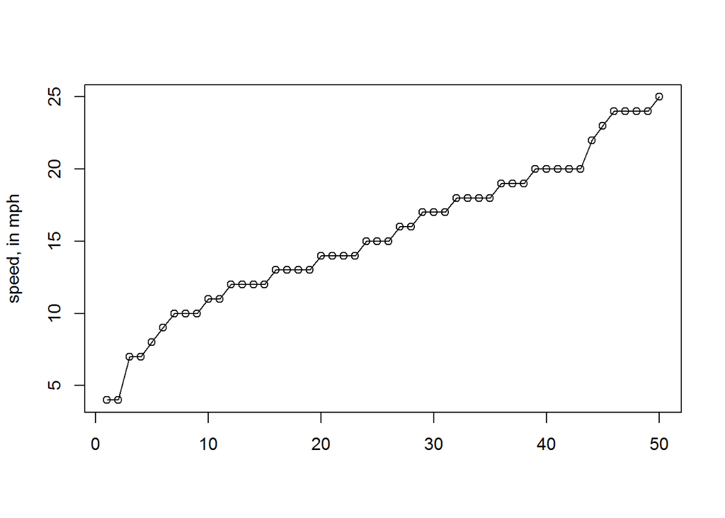